# Onsports

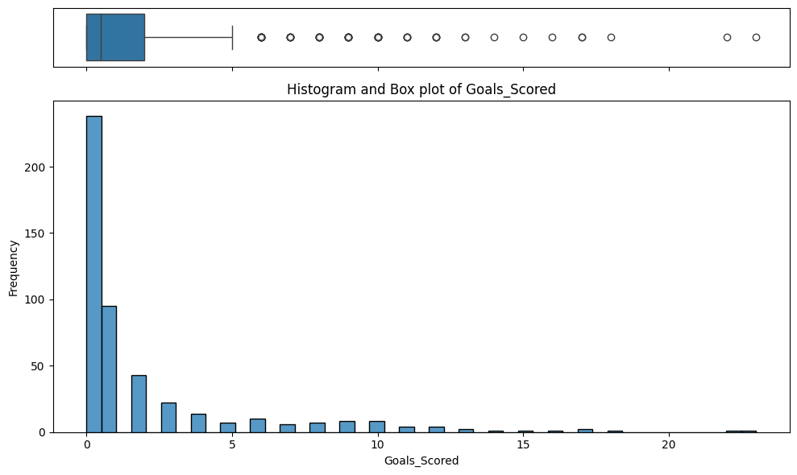

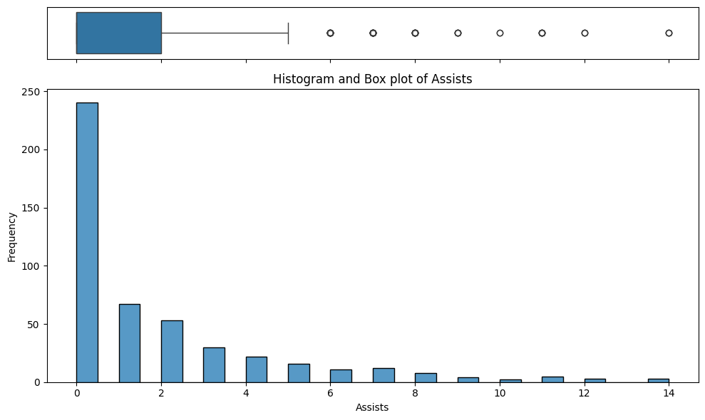

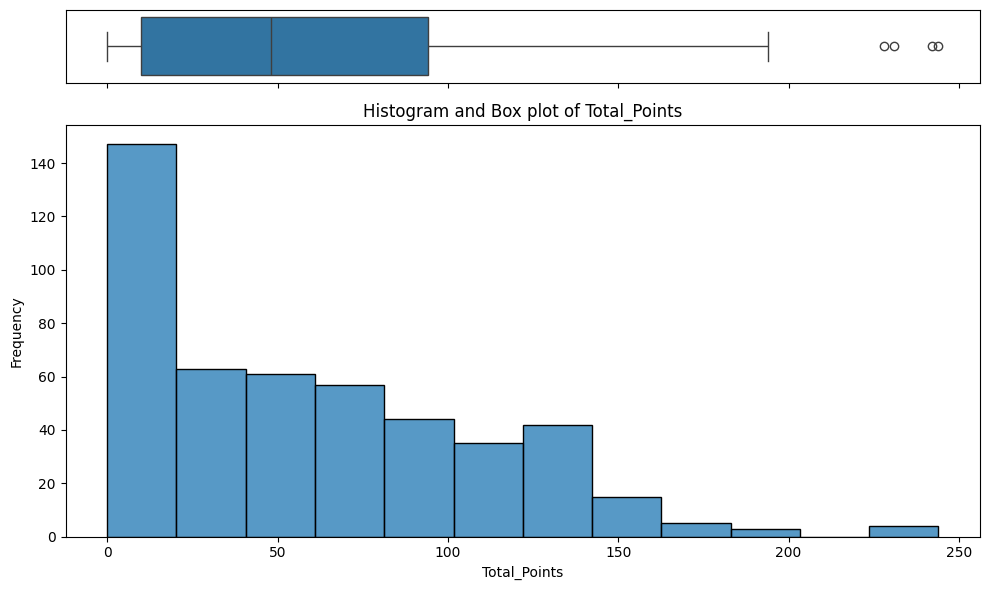

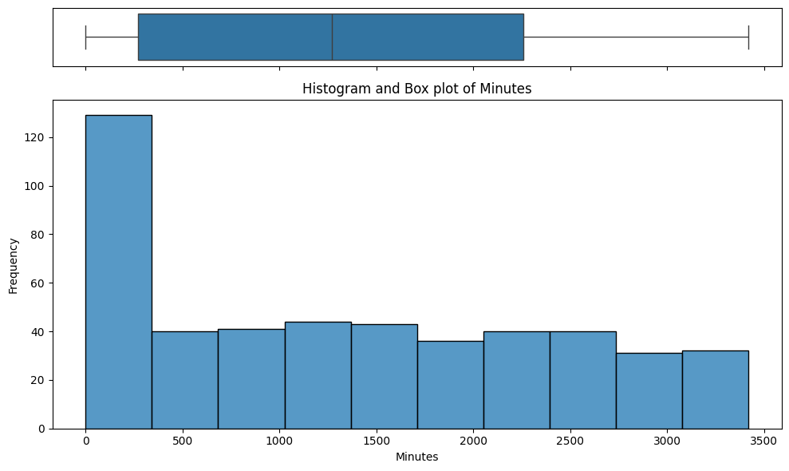

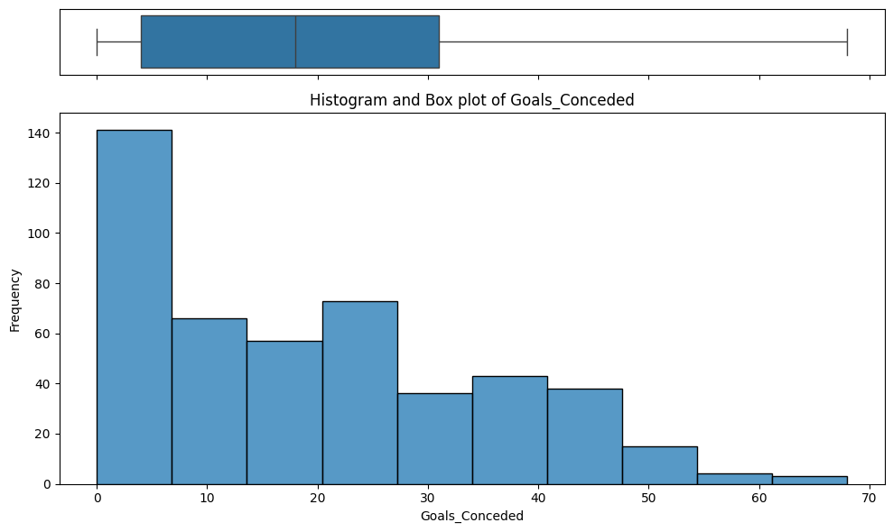

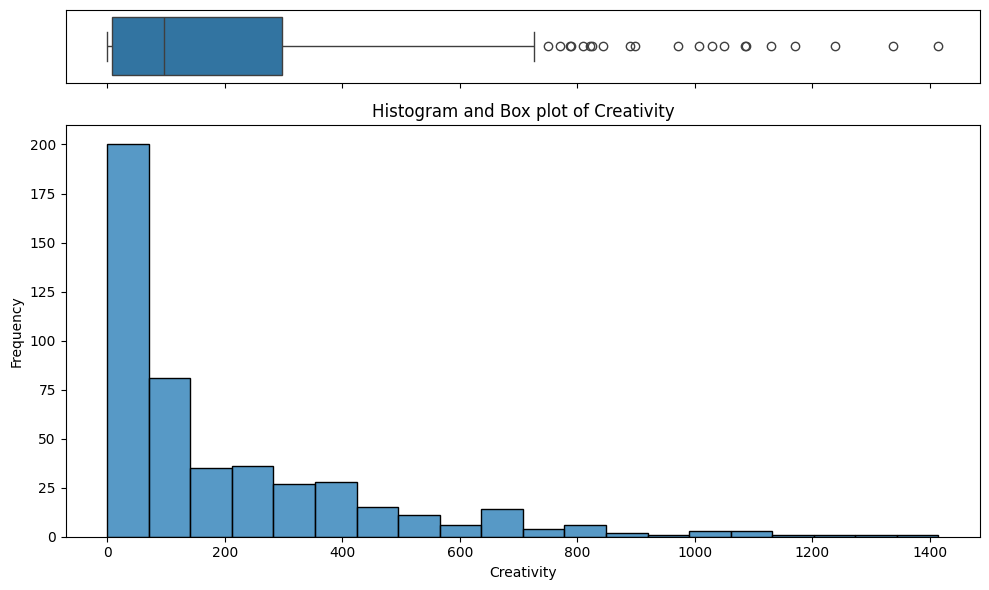

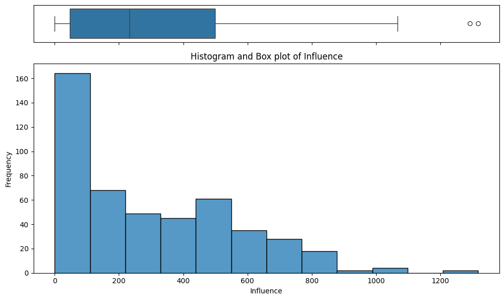

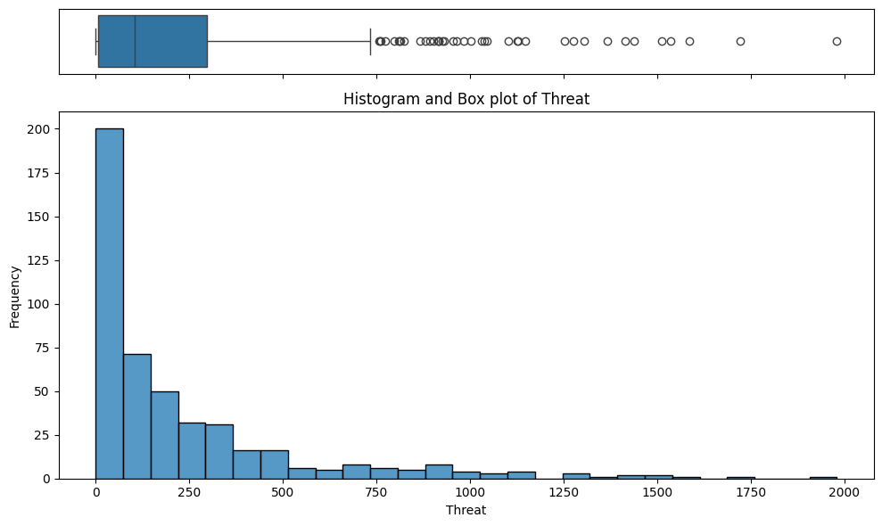

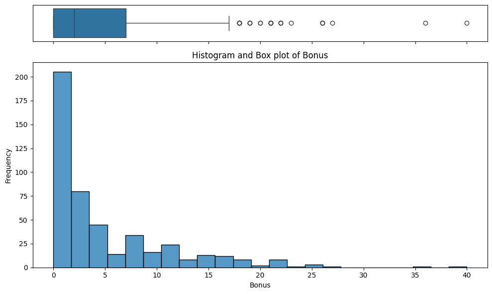

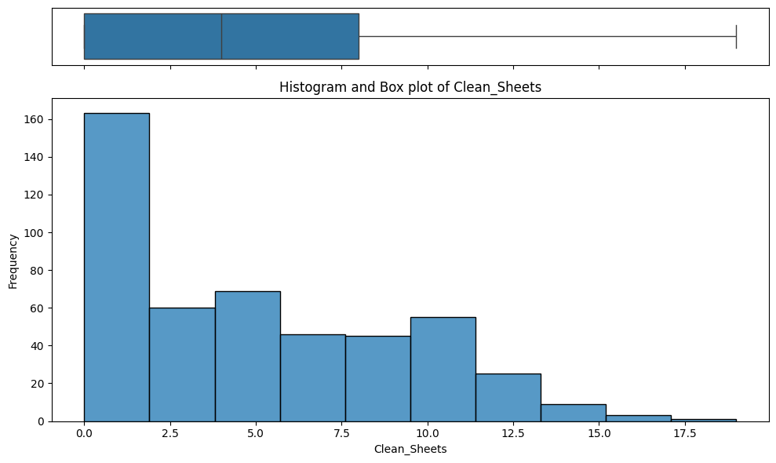

[figure not shown]

```python
import matplotlib.pyplot as plt
import seaborn as sns
import numpy as np  # Import numpy

def histogram_boxplot(data, column):
  """
  Creates a histogram and box plot for a numerical column.

  Args:
      data: Pandas DataFrame.
      column: Column name to plot.
  """
  fig, (ax_box, ax_hist) = plt.subplots(2, sharex=True, gridspec_kw={"height_ratios": (.15, .85)}, figsize=(10, 6))

  # Box plot
  sns.boxplot(data=data, x=column, ax=ax_box)
  ax_box.set(yticks=[])  # Remove ticks from box plot

  # Histogram
  sns.histplot(data=data, x=column, ax=ax_hist)

  plt.xlabel(column)  # Set x-axis label
  plt.ylabel('Frequency')  # Set y-axis label
  plt.title(f'Histogram and Box plot of {column}')  # Set plot title
  plt.tight_layout()  # Adjust layout to prevent labels from overlapping
  plt.show()

#create list of columns with numerical variables
num_col = df.select_dtypes(include=np.number).columns.tolist()

#display histograms and boxplots for all numerical columns
for col in num_col:
    histogram_boxplot(df, col)
```

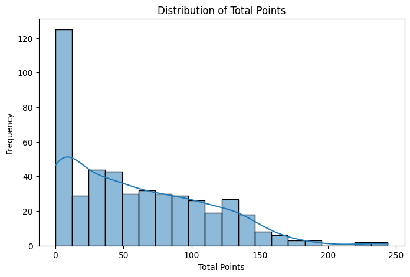

```python
plt.figure(figsize=(8,5))
sns.histplot(df["Total_Points"], bins=20, kde=True)
plt.title("Distribution of Total Points")
plt.xlabel("Total Points")
plt.ylabel("Frequency")
plt.show()
```

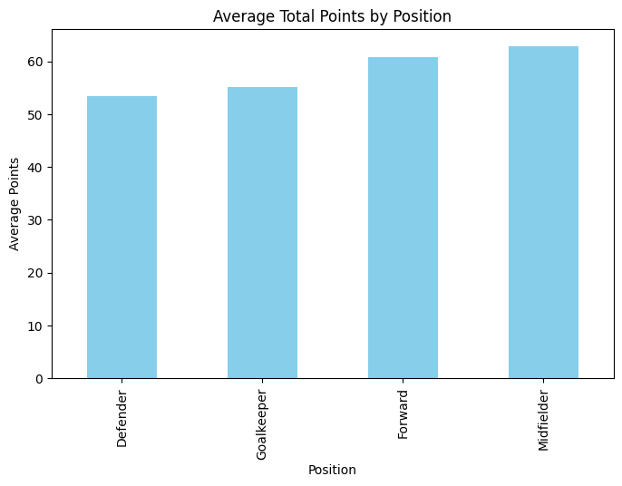

```python
avg_points = df.groupby("Position")["Total_Points"].mean().sort_values()
avg_points.plot(kind="bar", figsize=(8,5), color="skyblue")
plt.title("Average Total Points by Position")
plt.ylabel("Average Points")
plt.show()
```

[figure not shown]

```python
plt.figure(figsize=(14, 7))
sns.heatmap(
    df[num_col].corr(),
    annot=True,
    vmin=-1,
    vmax=1,
    fmt=".2f",
    cmap='viridis'
)
plt.show()
```

```python
import pandas as pd
import numpy as np
import matplotlib.pyplot as plt
import seaborn as sns
from sklearn.cluster import KMeans
from sklearn.preprocessing import StandardScaler
```

```python
# Assuming 'fpl_datapoints' was intended to be another column,
# replace 'P/E Ratio' with an actual column name from your DataFrame.
# For example, if the column you want to group by is 'Club'
# and calculate the mean of 'Total_Points', use this:
df.groupby('Club')['Total_Points'].mean().sort_values(ascending=False)
```

| Club | Total_Points |
| --- | --- |
| Manchester City | 78.666667 |
| Chelsea | 67.142857 |
| Liverpool | 66.851852 |
| Aston Villa | 65.615385 |
| Manchester United | 63.214286 |
| Tottenham Hotspurs | 60.689655 |
| Everton | 58.629630 |
| Leeds United | 58.310345 |
| West Ham United | 58.137931 |
| Leicester City | 57.896552 |
| Wolverhampton Wanderers | 55.423077 |
| Arsenal | 54.400000 |
| Southampton | 54.259259 |
| Brighton and Hove Albion | 53.464286 |
| Burnley | 52.925926 |
| Crystal Palace | 45.966667 |
| Newcastle United | 45.758621 |

**dtype:** float64

```python
features = ["Goals_Scored", "Assists", "Total_Points", "Minutes", "Creativity", "Influence", "Threat"]
data = df[features]
```

```python
scaler = StandardScaler()
scaled_data = scaler.fit_transform(data)
```

```python
inertia = []
k_range = range(1, 11)
```

```python
scaler = StandardScaler()
#create list of columns with numerical variables
num_col = df.select_dtypes(include=np.number).columns.tolist() # define num_col here
subset = df[num_col].copy()
subset_scaled = scaler.fit_transform(subset)
```

[figure not shown]

```python
subset_scaled_df = pd.DataFrame(subset_scaled, columns=subset.columns)
sns.pairplot(subset_scaled_df, height=2,aspect=2 , diag_kind='kde')
plt.show()
```

```python
for k in k_range:
    kmeans = KMeans(n_clusters=k, random_state=42, n_init=10)
    kmeans.fit(scaled_data)
    inertia.append(kmeans.inertia_)
```

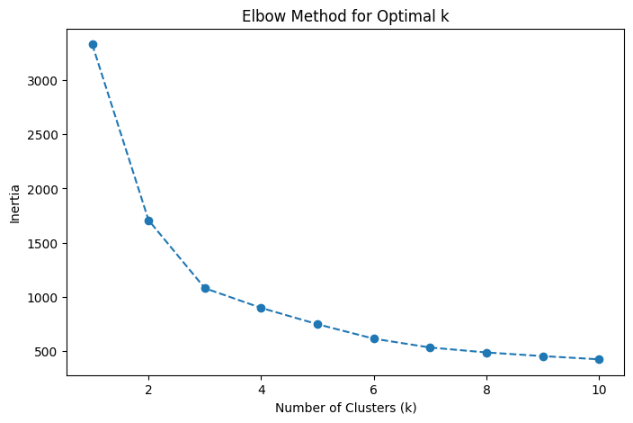

```python
plt.figure(figsize=(8,5))
plt.plot(k_range, inertia, marker="o", linestyle="--")
plt.xlabel("Number of Clusters (k)")
plt.ylabel("Inertia")
plt.title("Elbow Method for Optimal k")
plt.show()
```

```python
optimal_k = 3  # Adjust based on the elbow plot
kmeans = KMeans(n_clusters=optimal_k, random_state=42, n_init=10)
df["Cluster"] = kmeans.fit_predict(scaled_data)
```

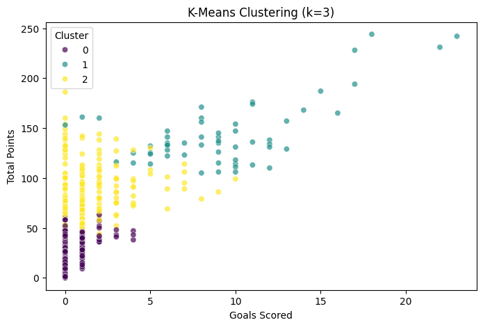

```python
plt.figure(figsize=(8,5))
sns.scatterplot(x=df["Goals_Scored"], y=df["Total_Points"], hue=df["Cluster"], palette="viridis", alpha=0.7)
plt.xlabel("Goals Scored")
plt.ylabel("Total Points")
plt.title(f"K-Means Clustering (k={optimal_k})")
plt.show()
```

```python
cluster_summary = df.groupby("Cluster")[features].mean()
print(cluster_summary)
```

```
         Goals_Scored   Assists  Total_Points      Minutes  Creativity  \
Cluster
0            0.329268  0.369919     17.654472   451.630081   49.087398
1            9.315789  6.877193    144.403509  2511.245614  624.573684
2            1.710983  2.028902     88.323699  2208.826590  263.632370

          Influence      Threat
Cluster
0         81.043902   55.142276
1        674.600000  903.807018
2        473.115607  242.774566
```

```python
features = ["Goals_Scored", "Assists", "Total_Points", "Minutes", "Creativity", "Influence", "Threat"]
data = df[features]
```

```python
scaler = StandardScaler()
scaled_data = scaler.fit_transform(data)
```

```python
!pip install scipy
import pandas as pd
import numpy as np
import matplotlib.pyplot as plt
import seaborn as sns
from sklearn.cluster import KMeans
from sklearn.preprocessing import StandardScaler
# Import the linkage function from scipy.cluster.hierarchy
from scipy.cluster.hierarchy import linkage

# ... (rest of your code) ...


linkage_matrix = linkage(scaled_data, method="ward")
```

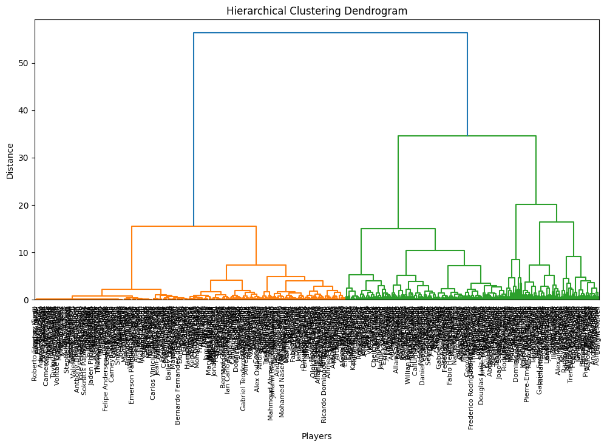

```python
!pip install scipy
import pandas as pd
import numpy as np
import matplotlib.pyplot as plt
import seaborn as sns
from sklearn.cluster import KMeans
from sklearn.preprocessing import StandardScaler
# Import both linkage and dendrogram functions
from scipy.cluster.hierarchy import linkage, dendrogram

# ... (rest of your code) ...


linkage_matrix = linkage(scaled_data, method="ward")
plt.figure(figsize=(12,6))
dendrogram(linkage_matrix, labels=df["Player_Name"].values, leaf_rotation=90, leaf_font_size=8)
plt.title("Hierarchical Clustering Dendrogram")
plt.xlabel("Players")
plt.ylabel("Distance")
plt.show()
```

```
<module 'matplotlib.pyplot' from '/usr/local/lib/python3.11/dist-packages/matplotlib/pyplot.py'>
```

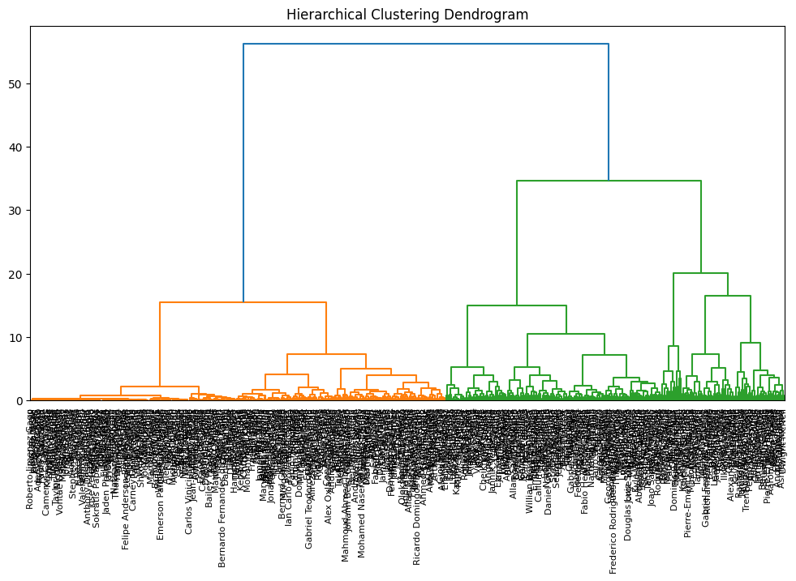

```python
!pip install scipy
import pandas as pd
import numpy as np
import matplotlib.pyplot as plt
import seaborn as sns
from sklearn.cluster import KMeans
from sklearn.preprocessing import StandardScaler
# Import both linkage and dendrogram functions along with fcluster
from scipy.cluster.hierarchy import linkage, dendrogram, fcluster

# ... (rest of your code) ...

linkage_matrix = linkage(scaled_data, method="ward")
plt.figure(figsize=(12,6))
dendrogram(linkage_matrix, labels=df["Player_Name"].values, leaf_rotation=90, leaf_font_size=8)
plt.title("Hierarchical Clustering Dendrogram")
plt
```

```python
features = ["Goals_Scored", "Assists", "Total_Points", "Minutes", "Creativity", "Influence", "Threat"]
data = df[features]
```

```python
scaler = StandardScaler()
scaled_data = scaler.fit_transform(data)
```

```python
from sklearn.decomposition import PCA  # Import PCA

features = ["Goals_Scored", "Assists", "Total_Points", "Minutes", "Creativity", "Influence", "Threat"]
data = df[features]

scaler = StandardScaler()
scaled_data = scaler.fit_transform(data)

pca = PCA(n_components=2)  # Reduce to 2 components for visualization
pca_result = pca.fit_transform(scaled_data)
```

```python
df["KMeans_clusters"] = kmeans.labels_
cluster_profile = df.groupby("KMeans_clusters")[num_col].mean()

# Assuming 'Current Price' is incorrect, replace with the actual column name
# For example, if the column is named 'Now_Cost', use:
cluster_profile["Count"] = (
    df.groupby("KMeans_clusters")["Player_Name"].count().values
)
cluster_profile.style.highlight_max(color="lightblue", axis=0)
```

[output not shown]

```python
df_pca = pd.DataFrame(pca_result, columns=["PC1", "PC2"])
df_pca["Player_Name"] = df["Player_Name"]  # Add player names
```

```python
pca = PCA(n_components=2)  # Keep first 2 components for analysis
pca_result = pca.fit_transform(scaled_data)
```

```python
loadings = pd.DataFrame(pca.components_.T, index=features, columns=["PC1", "PC2"])
```

```python
df_pca = pd.DataFrame(pca_result, columns=["PC1", "PC2"])
df_pca["Player_Name"] = df["Player_Name"]  # Adding player names
```

```python
inertia = []
k_range = range(1, 11)
```

```python
!pip install scipy
from scipy.cluster.hierarchy import linkage, cophenet # Import cophenet
from scipy.spatial.distance import pdist # Import pdist
import pandas as pd
import numpy as np
import matplotlib.pyplot as plt
import seaborn as sns
from sklearn.cluster import KMeans
from sklearn.preprocessing import StandardScaler


distance_metrics = ["euclidean", "chebyshev", "mahalanobis", "cityblock"]

# list of linkage methods
linkage_methods = ["single", "complete", "average", "weighted"]

high_cophenet_corr = 0
high_dm_lm = [0, 0]

for dm in distance_metrics:
    for lm in linkage_methods:
        Z = linkage(subset_scaled_df, metric=dm, method=lm)
        c, coph_dists = cophenet(Z, pdist(subset_scaled_df)) # Now cophenet is defined
        print(
            "Cophenetic correlation for {} distance and {} linkage is {}.".format(
                dm.capitalize(), lm, round(c,4)
            )
        )
        print(" ")
        if high_cophenet_corr < c:
            high_cophenet_corr = c
            high_dm_lm[0] = dm
            high_dm_lm[1] = lm
```

```
Cophenetic correlation for Euclidean distance and single linkage is 0.8562.

Cophenetic correlation for Euclidean distance and complete linkage is 0.8479.

Cophenetic correlation for Euclidean distance and average linkage is 0.8875.

Cophenetic correlation for Euclidean distance and weighted linkage is 0.837.

Cophenetic correlation for Chebyshev distance and single linkage is 0.7844.

Cophenetic correlation for Chebyshev distance and complete linkage is 0.8558.

Cophenetic correlation for Chebyshev distance and average linkage is 0.8871.

Cophenetic correlation for Chebyshev distance and weighted linkage is 0.8744.

Cophenetic correlation for Mahalanobis distance and single linkage is 0.8182.

Cophenetic correlation for Mahalanobis distance and complete linkage is 0.649.

Cophenetic correlation for Mahalanobis distance and average linkage is 0.8045.

Cophenetic correlation for Mahalanobis distance and weighted linkage is 0.8033.

Cophenetic correlation for Cityblock distance and single linkage is 0.8712.

Cophenetic correlation for Cityblock distance and complete linkage is 0.8484.

Cophenetic correlation for Cityblock distance and average linkage is 0.8558.

Cophenetic correlation for Cityblock distance and weighted linkage is 0.8486.
```

```python
for k in k_range:
    kmeans = KMeans(n_clusters=k, random_state=42, n_init=10)
    kmeans.fit(df_pca[["PC1", "PC2"]])
    inertia.append(kmeans.inertia_)
```

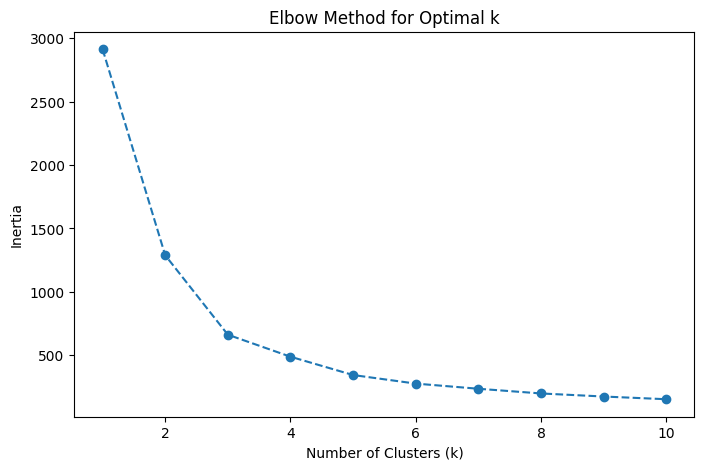

```python
plt.figure(figsize=(8,5))
plt.plot(k_range, inertia, marker="o", linestyle="--")
plt.xlabel("Number of Clusters (k)")
plt.ylabel("Inertia")
plt.title("Elbow Method for Optimal k")
plt.show()
```

```python
optimal_k = 3  # Adjust based on elbow plot
kmeans = KMeans(n_clusters=optimal_k, random_state=42, n_init=10)
df_pca["Cluster"] = kmeans.fit_predict(df_pca[["PC1", "PC2"]])
```

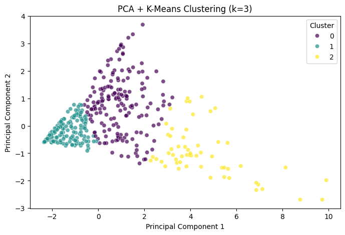

```python
plt.figure(figsize=(8,5))
sns.scatterplot(data=df_pca, x="PC1", y="PC2", hue=df_pca["Cluster"], palette="viridis", alpha=0.7)
plt.title(f"PCA + K-Means Clustering (k={optimal_k})")
plt.xlabel("Principal Component 1")
plt.ylabel("Principal Component 2")
plt.show()
```

```python
df["Cluster"] = df_pca["Cluster"]
```

```python
cluster_summary = df.groupby("Cluster")[features].mean()
print("Cluster Summary:\n", cluster_summary)
```

```
Cluster Summary:
          Goals_Scored   Assists  Total_Points      Minutes  Creativity  \
Cluster
0            1.751445  1.988439     88.306358  2198.849711  262.624277
1            0.329268  0.369919     17.654472   451.630081   49.087398
2            9.192982  7.000000    144.456140  2541.526316  627.633333

          Influence      Threat
Cluster
0        472.661272  244.884393
1         81.043902   55.142276
2        675.978947  897.403509
```

```python
cluster_profile.style.highlight_max(color="lightgreen", axis=0)
```

[output not shown]

**Insights:**

The data set has 476 rows and 14 columns which has various attributes in it. which includes goals scored, assists, total points, minutes played, creativity, influence, and defensive stats. It includes player statistics like goals scored, assists, total points, minutes played, goals conceded, and defensive stats (clean sheets, bonus). Players are categorized by position: Goalkeeper, Defender, Midfielder, and Forward. Metrics like Creativity, Influence, and Threat indicate playstyle.

**Recommendation:**

1. Dimensions has to be reduced.
2. Players clusters should be analysed
3. Players has to be catagorised based on their status.
4. Team selection has to be done based on individual scores and performance.
5. Player roles has to be identified during the selction process and then players have to be selected.
6. Performance trends makes a huge impact while selecting the players team.
7. Potential focus should be made on areas like injury prevention, player development, or optimizing game strategies; consider incorporating factors like gender equality, accessibility, and youth sports development in your research as well.